# R Notebook

# Maternal healthcare disparities

## 🧭 Introduction

This project explores a maternal healthcare dataset sourced from the CDC WONDER program. The dataset contains state-level aggregated birth records for 2019, including information on maternal characteristics (e.g., age, BMI), prenatal care (number of prenatal visits), birth outcomes (birth weight), and risk factors (tobacco use, pre-pregnancy diabetes, pre-pregnancy hypertension, prior infant deaths). Each row represents aggregated data for a state, including a set of key risk-indicator variables with summary statistics.

Improving maternal and infant health is a priority for public health agencies, and this dataset allows us to investigate patterns, disparities, and potential risk groupings that might inform targeted interventions.

## 🎯 Objectives

The goals of this analysis are:

1. **Examine prenatal care by risk factors**  
   Investigate whether mothers with certain risk factors (e.g., smoking, diabetes, hypertension) receive different levels of prenatal care.
2. **Identify key associations**  
   Use correlation analysis and visualizations to find the strongest relationships among numerical variables (e.g., age, BMI, birth weight, prenatal visits, interval since last birth).
3. **Cluster maternal risk profiles**  
   Reduce dimensionality using PCA and apply K-means clustering on the principal components to identify meaningful risk profile groups.
4. **Map state-level risk profiles**  
   Aggregate cluster assignments at the state level and visualize the geographic distribution of similar maternal risk profiles across the U.S.

## 🛠️ Project Workflow Overview

| Step | Description |
| --- | --- |
| 1️⃣ Data Cleaning & Transformation | Handle missing values, encode categorical variables, remove `"Unknown"` entries |
| 2️⃣ Exploratory Data Analysis | Create bar charts and scatter plots to explore relationships between risk factors and outcomes |
| 3️⃣ Correlation Analysis | Generate a heatmap and perform pairwise scatter plots to identify strong numeric relationships |
| 4️⃣ Dimensionality Reduction | Conduct PCA and examine explained variance and scree plots |
| 5️⃣ Clustering | Perform K-means clustering on the first 4 principal components and determine optimal `k` |
| 6️⃣ Geographic Visualization | Map cluster assignments to states to identify regional patterns |

*Proceed below to explore each step with code, visualizations, and interpretation.*

```r
library(tidyverse)
library(ggcorrplot)
library(cowplot)
library(usmap)
theme_set(theme_light())
maternal <- read_csv("https://raw.githubusercontent.com/36-SURE/2025/main/data/maternal.csv")
```

## Exploratory Data Analysis

```r
summary(maternal)
```

```
    State           PriorBirthsNowDeceased  TobaccoUse        PrePregnancyDiabetes
 Length:708         Min.   : 0.0000        Length:708         Length:708
 Class :character   1st Qu.: 0.0000        Class :character   Class :character
 Mode  :character   Median : 0.0000        Mode  :character   Mode  :character
                    Mean   : 0.8861
                    3rd Qu.: 1.0000
                    Max.   :12.0000
 PrePregnancyHypertension     Births         AverageMotherAge AverageBirthWeight AveragePrePregnancyBMI
 Length:708               Min.   :    10.0   Min.   :25.08    Min.   :2154       Min.   :20.41
 Class :character         1st Qu.:    23.0   1st Qu.:29.40    1st Qu.:2940       1st Qu.:27.51
 Mode  :character         Median :    79.5   Median :30.73    Median :3085       Median :29.77
                          Mean   :  5258.8   Mean   :30.71    Mean   :3074       Mean   :30.72
                          3rd Qu.:   520.2   3rd Qu.:32.02    3rd Qu.:3237       3rd Qu.:33.50
                          Max.   :426990.0   Max.   :38.18    Max.   :3947       Max.   :46.31
 AverageNumberPrenatalVisits AverageIntervalSinceLastBirth       id
 Min.   : 3.32               Min.   : 18.00                Min.   :  1.0
 1st Qu.:10.09               1st Qu.: 47.90                1st Qu.:220.8
 Median :11.24               Median : 55.63                Median :432.5
 Mean   :11.27               Mean   : 57.20                Mean   :426.2
 3rd Qu.:12.59               3rd Qu.: 64.19                3rd Qu.:630.2
 Max.   :16.73               Max.   :144.67                Max.   :842.0
```

### Question1:

Does an increased number of prenatal visits correlate with risk factors (tobacco use, diabetes, hypertension)?

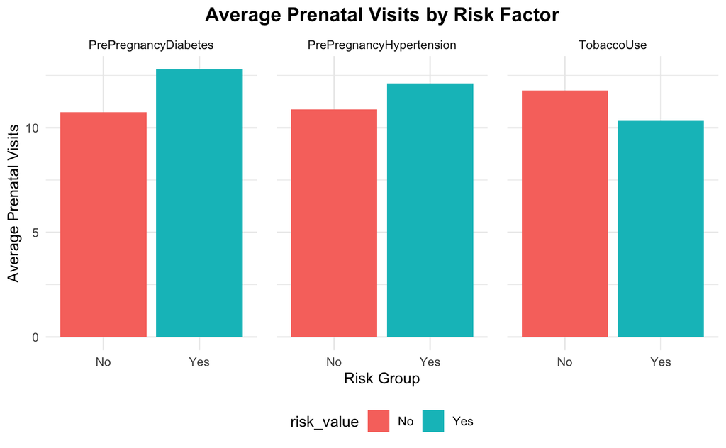

### Question2:

Are there strong correlations among the numeric variables in the data-set? If so, what are the most important ones, and how might they be related?

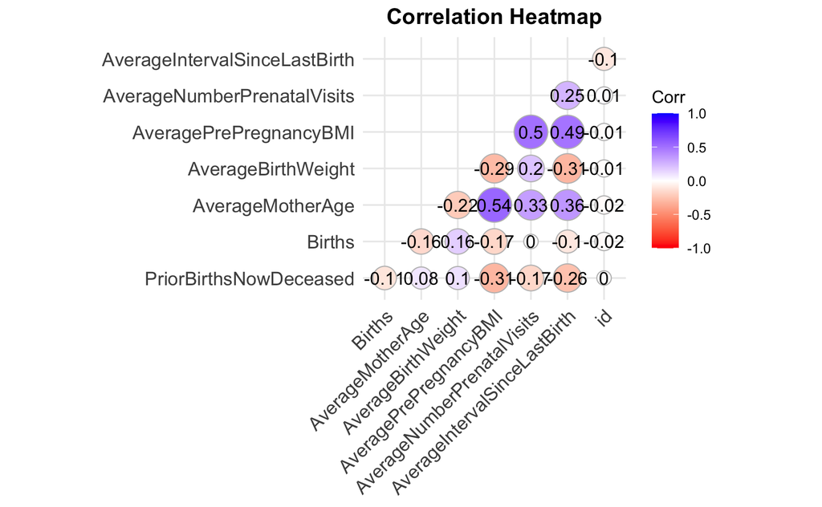

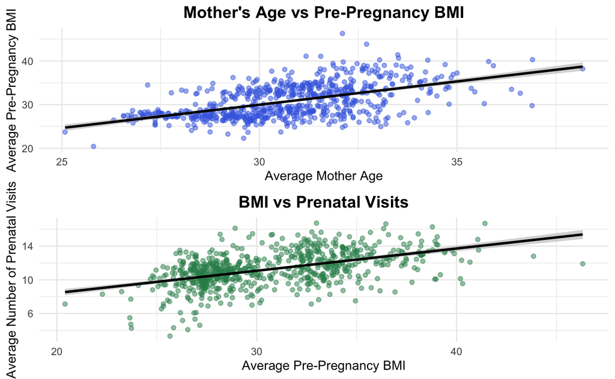

```r
# Plot 1: Mother's Age vs Pre-Pregnancy BMI
plot1 <- maternal |>
  ggplot(aes(x = AverageMotherAge,
             y = AveragePrePregnancyBMI)) +
  geom_point(alpha = 0.5, color = "royalblue") +
  geom_smooth(method = "lm", color = "black") +
  labs(
    title = "Mother's Age vs Pre-Pregnancy BMI",
    x = "Average Mother Age",
    y = "Average Pre-Pregnancy BMI"
  ) +
  theme_minimal() +
  theme(plot.title = element_text(hjust = 0.5,
                                  size = 14,
                                  face = "bold"))

# Plot 2: BMI vs Prenatal Visits
plot2 <- maternal |>
  ggplot(aes(x = AveragePrePregnancyBMI,
             y = AverageNumberPrenatalVisits)) +
  geom_point(alpha = 0.5, color = "seagreen") +
  geom_smooth(method = "lm", color = "black") +
  labs(
    title = "BMI vs Prenatal Visits",
    x = "Average Pre-Pregnancy BMI",
    y = "Average Number of Prenatal Visits"
  ) +
  theme_minimal() +
  theme(plot.title = element_text(hjust = 0.5,
                                  size = 14,
                                  face = "bold"))

plot_grid(plot1, plot2, nrow = 2)
```

## Clustering analysis

Do certain states form similar risk profiles?

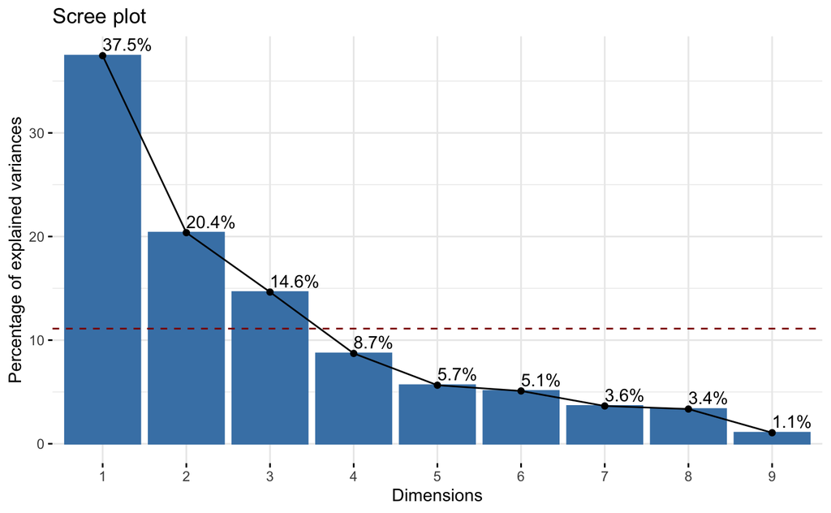

## Apply K-Means clustering

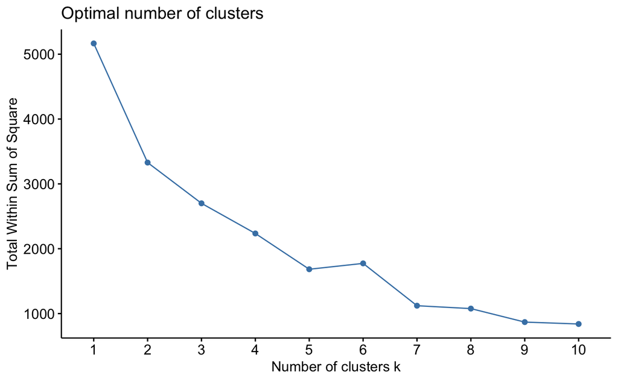

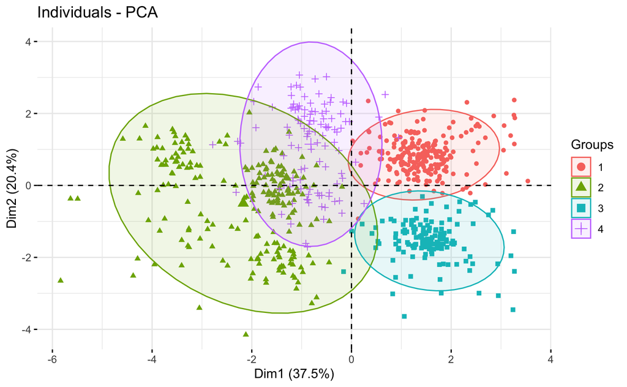

## Visualize clusters by State

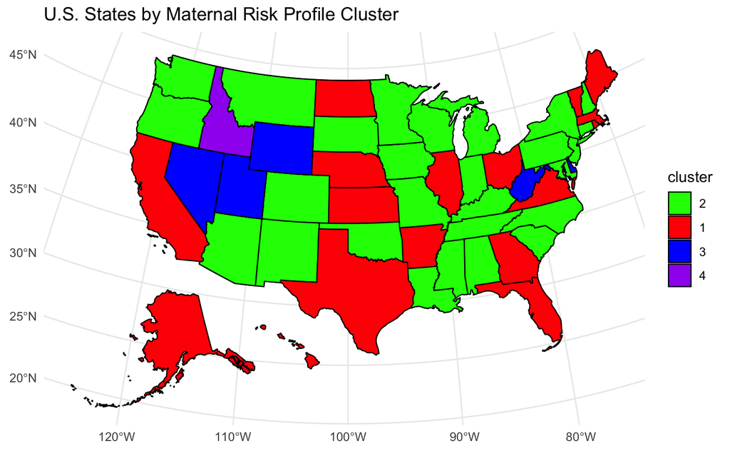